# Sometimes you just need words

I’m Lewis Kirvan, I’m a research manager at the Consumer Finance Protection Bureau. Today I’m talking about how important words are for data analysts.

## A story with two chapters:

1. When you need more words.
2. How to make words (a bit) easier!

This talk is pretty simple. The first part is about recognizing how important words are for communicating about data. Sure data visualizations are cool, but have you heard of paragraphs? But, seriously, I work in a reasonably data driven organization. Still I’d wager that basically none of the decision-makers in my organization have run a regression recently. Effective communication runs through the the words that accompany your analysis. And effective communication is a big way to stand out as a data person. That’s my pitch at least.

The second part of this talk presents a few tips for making it easy to work with words. Especially when you want to generate text based on your data.

# Chapter 1:

When you need more words

## Possibly the most familiar diagram at this conference

[figure not shown]

I think everyone has probably seen this diagram from R for data science. It really does explain a lot of what happens when making data products. But I think it leaves off one important thing.

# You are in the middle of that cycle

[figure not shown]

there you are. looking cool. hands on your hips. So why does this matter? Well, you are building up context for the data and for your analysis during that cycle.

## Some Stuff you might do along the way:

- Look at the application that generates the data
- Read the survey instrument
- Talk to application users
- Read data documentation (if you are so lucky)
- Read relevant research
- Talk to experts that know about how and why the data was generated

this stuff is all data science too. it’s important! if you don’t really understand the context of your data it’s easy to make mistakes. So this stuff is important and shouldn’t be undersold.

Time to communicate

At some point, or more likely at several points you will do some communication about your data or your analysis! Yay, this part is fun.

Time to communicate think about your audience

Bring people along on your journey

Remember all that context you built up? A good first question to ask yourself is “how much of that context is shared by my audience”. How much do you have to pack, to get your audience happily to their destination.

## Two limit cases: Congress | your immediate team

[figure not shown]

I’m going to talk about a couple of quick examples that demonstrate the range of packing you might do for your journey.

## Congress

[figure not shown]

- 6 charts
- 2 tables
- 50 pages of context

*POST*

- congress needs a lot of stuff
- explaining and defining key terms
- describing the data collection in detail
- describe the legal framework and rules that govern the collection

## Two limit cases: Congress | your immediate team

[figure not shown]

## your immediate team

[figure not shown]

- 3 charts
- 6 KPIs
- less than a paragraph of text
- Labels come directly from data elements
- Terse chart titles
- KPIs presented with minimal explanation because everyone understands them.

## Less shared context means more context (AKA WORDS) needs to be included in your product.

```r
library(tidyverse)
```

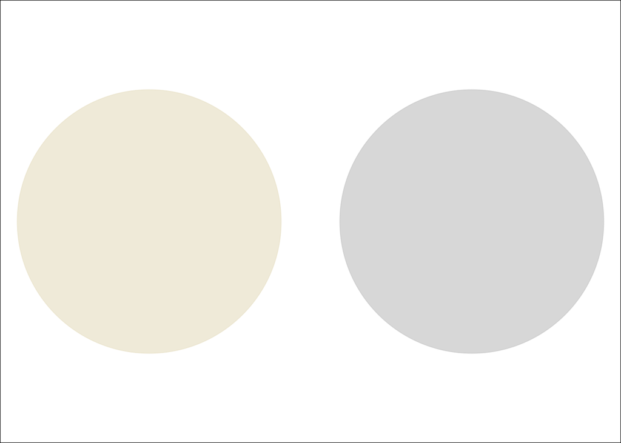

```r
this_theme <- function(gg){

  gg +
    theme_void() +
    theme(
      panel.background = element_rect(fill='transparent')
      , plot.background = element_rect(fill='transparent', color=NA)
      , panel.grid.major = element_blank()
      , panel.grid.minor = element_blank()
      , legend.background = element_rect(fill='transparent')
      , legend.box.background = element_rect(fill='transparent')
      )

}

circle <- function(gg
                   , size = 100
                   , color = "black"
                   , x = 0
                   , y = 0){

  gg +
    geom_point(aes(x = x, y = y)
               , size = size
               , color = color
               , alpha = .75)
   }

ggplot(data = NULL)  %>%
  circle(color = "#eee8d5", x = -1) %>%
  circle(color = "light grey", x = 1, y = 0) %>%
  this_theme() +
  xlim(-1.75, 1.75)
```

## More shared context means you can include less context in your product (but you still document it!)

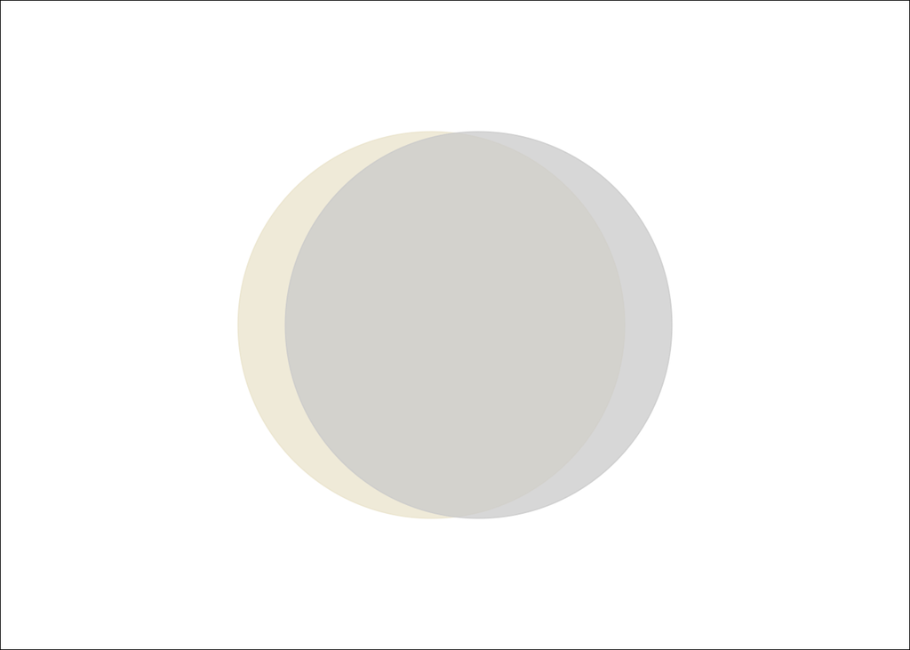

```r
ggplot(data = NULL)  %>%
  circle(color = "#eee8d5", x = -0.1) %>%
  circle(color = "light grey", x = 0.1, y = 0) %>%
  this_theme() +
  xlim(-1.75, 1.75)
```

## Example : Moving from team communication to external communication

[figure not shown]

- interactive Tableau dashboard
- high chart density (dozens!)
- field names correspond to internal system

PRE: I like this example because it’s the same data but presented to two different audiences POST: This is a pretty classic team KPIs kind of reporting dashboard. When the team went to draft the external version of this report they repurposed a lot of this dashboard, because it’s what they are used to.

## Example : Moving to an External audience of bank employees

[figure not shown]

- 3 simple static charts
- Some of the charts from the internal dashboard are now sentences!
- Names are defined in an introduction
- Different explanatory paragraphs are included depending on data

*PRE* this is when I entered the project. And I knew that we wanted this document to travel. We wanted people at the bank to be able to share it. So it’s context had to travel with the document.

*post* - It’s actually easier and denser to tell people what the chart means directly in words instead of putting the chart in there, and describing it and hoping someone gets the point.

- And we conditionally only the text that is relevant to save on time.

## key factors

External

Less technical

Decision makers

Time crunched

- *external* people don’t share much context at all
- *external* doesn’t have just one meaning. there’s external to your team, external to your office and external to your organization
- *technical* watch out for specialized charts–> don’t just present a ROC curve
- *decision makers* need appropriate context to trust your analysis. If they don’t get they can’t make a decision. This is something I’ve seen alot and something that’s happened to me when presenting to senior people.
- *time crunched* isn’t super intuitive–but if someone is time-crunched they won’t look up the context themselves. So you’ve got one shot!

that’s chapter one, hopefully this is a helpful way to think about communicating and will help you identify when you might be in the universe of needing more words in your analysis.

# Chapter 2:

How to make words (a bit) easier!

RMARKDOWN RMARKDOWN RMARKDOWN RMARKDOWN

QUARTO QUARTO QUARTO QUARTO QUARTO QUARTO QUARTO QUARTO

## Tips

Use templates

Use design resources

Partner up

## Tip 1 Use a template language or string interpolation

```r
knitr::knit_engines$set(whisker = function(options ){

  if(purrr::is_empty(options$data)){
    options$data <- globalenv()
  }

  whisker::whisker.render(
    template = options$code
    , data = options$data
    , partials = options$partials
  )
  })
```

*PRE* The context here is building up generated text. When you’re building text your environment will get cluttered. Your markdown file, littered with calculations will be hard to read.

This idea is a partial solution. Generating text is hard and tedious Take all the help you can get.

This function registers a language engine for mustache templates. It takes a template (basically markdown with variables) and some data and marries them together.

## Tip 1 Use a template language or string interpolation

```r
knitr::knit_engines$set(glue = function(options ){

  if(purrr::is_empty(options$data)){
    options$data <- globalenv()
  }

  glue::glue(
    options$code
    , .envir = options$data
  )
  })
```

## Tip 1A use lists as a ‘namespace’

```r
whisker_data <- list(
  species = "virginica"
  , mean_length =  iris %>%
    filter(Species == "virginica") %>%
    pull(Petal.Length) %>%
    mean()
  , overall_mean = mean(iris$Petal.Length)
  , field_name = "petal length"
  , other = iris %>%
    filter(Species != "virginica") %>%
    pull(Species) %>%
    unique() %>%
    as.character() %>% str_pad(., width = nchar(.) + 1)
)

whisker_data$greater_less <- with(
  whisker_data
  , ifelse(mean_length > overall_mean
           , "longer"
           , "shorter")
  )
```

PRE: And here’s where we make the data. this is nice! It’s a little namespace for the variables you need to fill your template. It reduces the amount of clutter in your environment and for me at least reduces some of the mental load on you as a developer. Plus naming things is hard…you might calculate ten different means, it’s hard to keep differentiating them. Stick them in lists for the sections of your report instead.

## Tip 1A use lists as a ‘namespace’

A typical {{species}} iris has {{greater_less}} {{field_name}} than other iris species ({{other}}).

A typical virginica iris has longer petal length than other iris species ( setosa, versicolor).

“A typical virginica iris has longer petal length than other iris species ( setosa, versicolor).”

Mustache is intentionally very simple, but it does have a couple of other nice features. I use it to create conditional text that depends on some data element passing a threshold or being present in the data. This same pattern works with GLUE and glue.

# Tip 2 : Use existing design resources

design reallly matters for documents with lots of words. style consistency and signposting are one of the big differences between a good document and an unreadable one. There’s a good chance that someone in your org has put a lot of thought into how to communicate.

## Tip 2A Use existing document templates so you never have to copy+paste again

it’s almost as easy as this:

```yaml
format:
  docx:
    reference-doc:
      custom-reference-doc.docx
```

```yaml
format:
  docx:
    reference-doc:
      cool-org-document.docx
```

So, I’m a pretty data analysts in that I have degrees in African History and a JD. I spent the first 30-ish years of my life trying to make effective documents. Let’s look at an example. John Hopkins published the covid dashboard throughout the pandemic. Millions of people visited the dashboard – it was interesting; it allowed people to dig into their local area. But what were people talking about? They were talking about a few stats and stories of hospitals and people who were sick. Dashboards are great for exploring. Words and narrative are great for communicating.

So what makes a good document; consistency and signposting. If you are in a big organization it’s likely that someone has probably thought about how to make consistent documents and documents that are well signposted. Use them here! You can just stick the file in to your yaml and make sure it works. OR go the extra mile and make it into a simple package. I’ve done this with some of the document templates at my work and it’s awesome. Plus you never have to copy and paste into word or PowerPoint again.

## Tip 2A Use existing document templates

Then use pandoc to reference your fancy custom styles like so:

```markdown
:::{custom-style="pull-quote"}
Put your qutation here!
:::
```

[figure not shown]

## Tip 2B Package up your design system

A minimal package that will save you tons of time:

1. put your organization color system in an easy to access list
2. a ggplot theme that gets you most of the way to publication ready

this is cheating, because it’s not strictly about using words, but it’s such a great time saver in producing reports and documents that I can’t not include it. Someone at my org did this and I love them for it. basically everyday.

## Partner with a writer

They can help you with lots of stuff:

- grammar, the grammar for language
- an outside opinion (does this make sense?)
- thinking even more about what your audience cares about.

Writing is hard! And it’s sometimes especially hard for smart analytical people. You expect to much of your audience to be honest.